# Corona-Dashboard der Stadt Passau

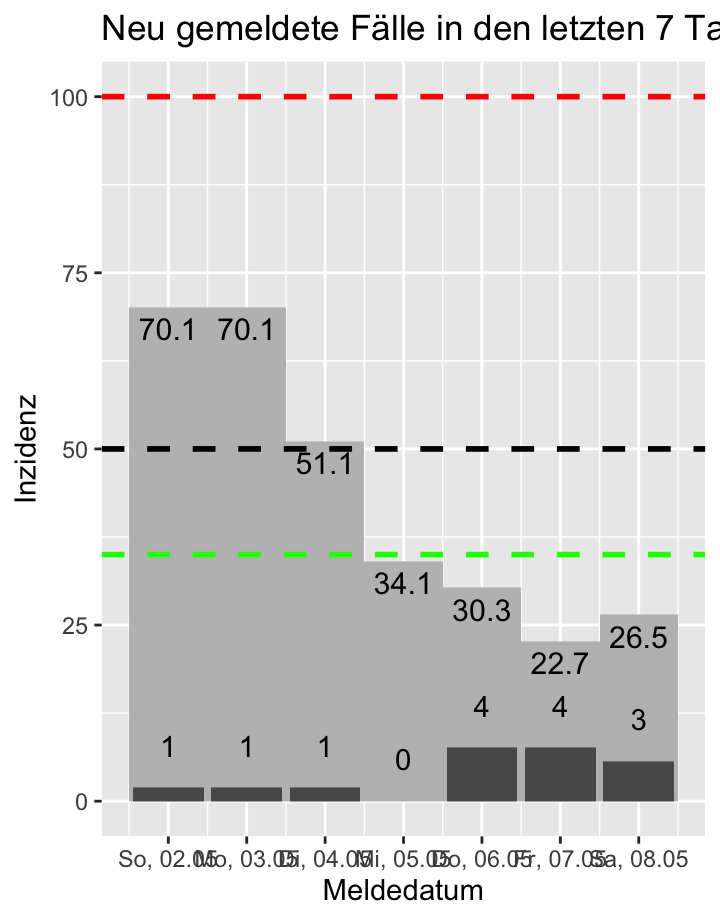

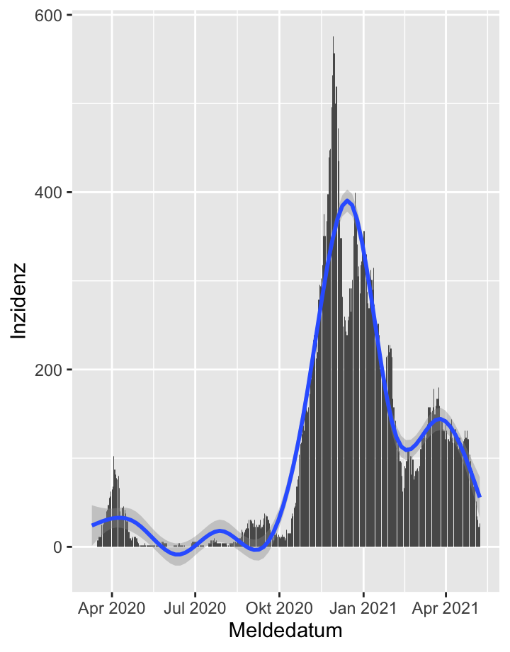

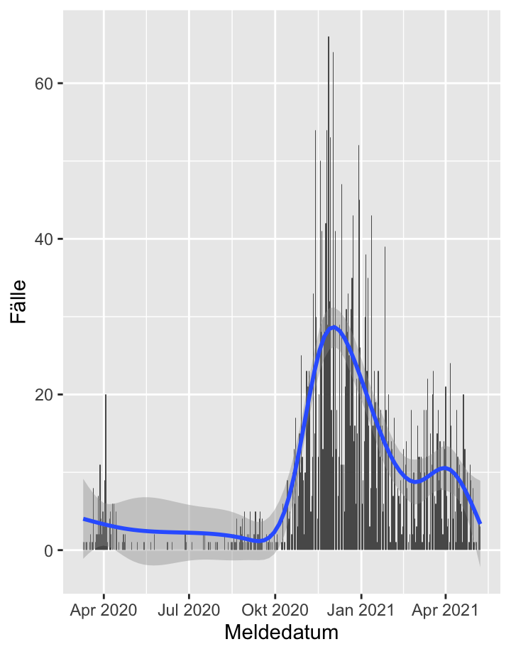

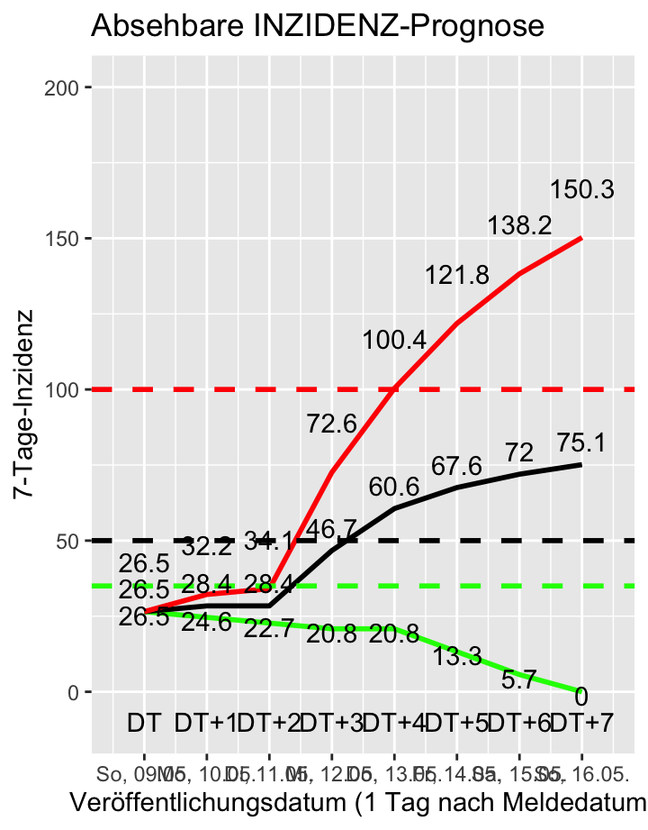

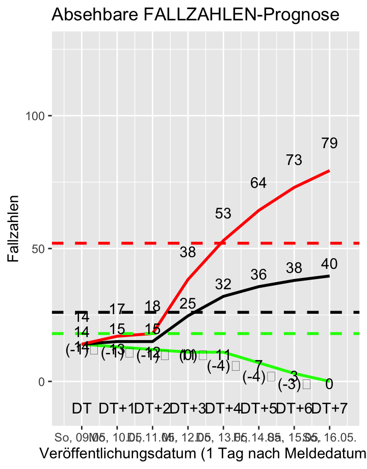

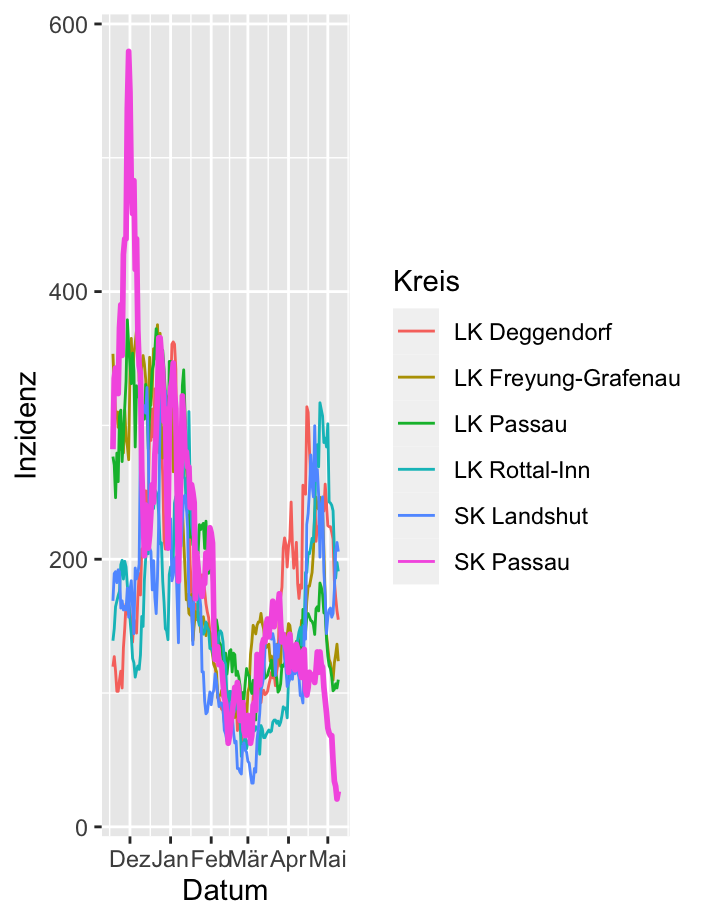

# Diagramme zur aktuellen Inzidenz

### Inzidenz am Sa, 08.05.2021

[interactive chart not shown]

### 7-Tage-Inzidenz: Übersicht

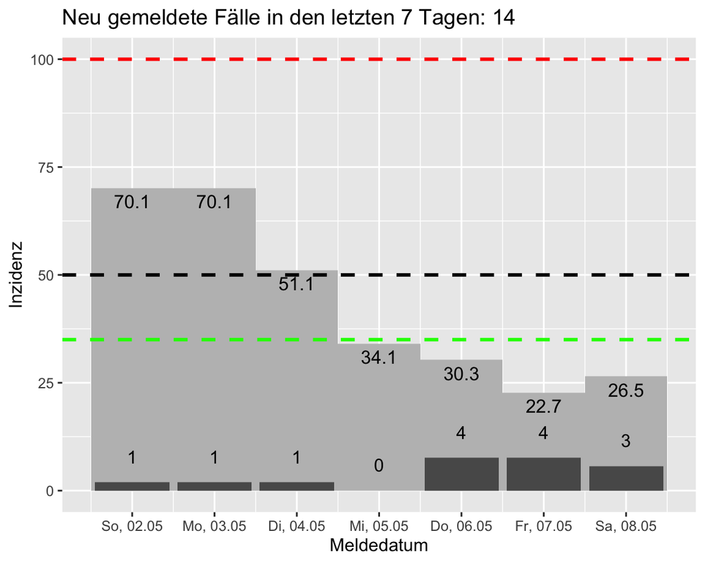

### Entwicklung der Inzidenzen

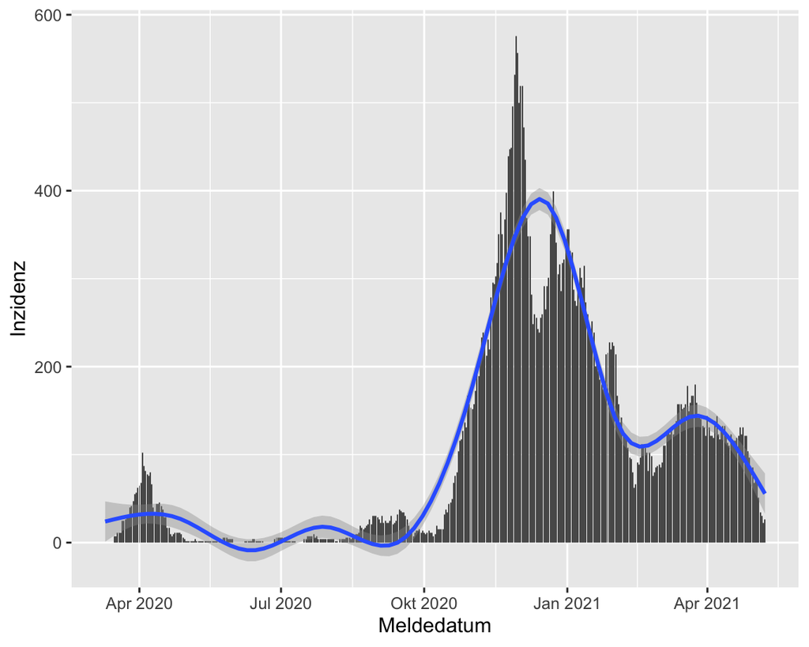

### Fälle pro Tag

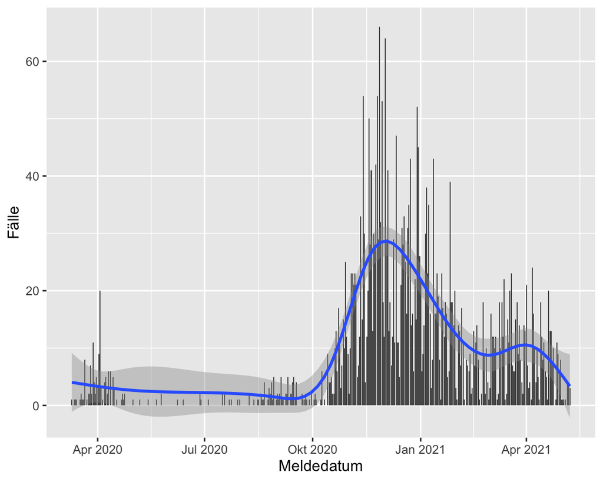

# Strukturdaten

## Details zu Inzidenz und Altersstruktur

### Heute neu

| Meldedatum | Art | Inzidenzrelevant | Fallzahl | A00-A04 | A15-A34 |
| --- | --- | --- | --- | --- | --- |
| 2021-05-07 | Neu | Ja | 1 | 0 | 1 |
| 2021-05-08 | Neu | Ja | 3 | 1 | 2 |

### Altersstruktur

“Kohorteninzidenz” steht für die getrennt nach Altersgruppen (“Kohorten”) ausgewiesene 7-Tage-Inzidenz. Diese wird von RKI bislang nicht veröffentlicht, da hierfür die lokale Altersstruktur bekannt sein muss.

NA = “Not Available”, d.h. kein Fall in dieser Altersklasse gemeldet

|  | A00-A04 | A05-A14 | A15-A34 | A35-A59 | A60-A79 | A80+ |
| --- | --- | --- | --- | --- | --- | --- |
| Fälle | 1 | 2 | 6 | 5 | NA | NA |
| EWO | 2138 | 3180 | 15820 | 16601 | 11298 | 3744 |
| Kohorteninzidenz | 46.8 | 62.9 | 37.9 | 30.1 | NA | NA |

### Grenzwerte

“max. Fallzahl” steht für die höchste Fallzahl, die den jeweiligen Grenzwert noch einhält. “Abweichung” beschreibt, wie weit man über oder unter dieser Fallzahl liegt (“0” ist somit die Punktlandung).

BITTE BEACHTEN: Die Anzahl der Tage, seit denen ein Schwellenwert unterschritten wird, kann auf zweierlei Wegen bestimmt werden:

- bezogen auf die täglichen Veröffentlichungen im RKI-Dashboard (ohne Berücksichtigung nachträglicher Änderungen), oder
- bezogen auf die für den zurückliegenden 7-Tage-Zeitraum in der RKI-Datenbank enthaltenen Inzidenzwerte (mit Berücksichtigung nachträglicher Änderungen)

Rechtlich relevant ist die Berechnung **OHNE** Änderungen, d.h. hier die Spalte “Tage lt. Dashboard”.

| Grenzwert | max. Fallzahl | Abweichung | Tage lt. Datenbank | Tage lt. Dashboard |
| --- | --- | --- | --- | --- |
| 35 | 18 | -4 | 4 | 0 |
| 50 | 26 | -12 | 4 | 0 |
| 100 | 52 | -38 | 11 | 0 |
| 150 | 79 | -65 | 44 | 0 |

# Ausblick auf die nächsten 7 Tage

## Blick in die Kristallkugel

### Prognose der Inzidenzen

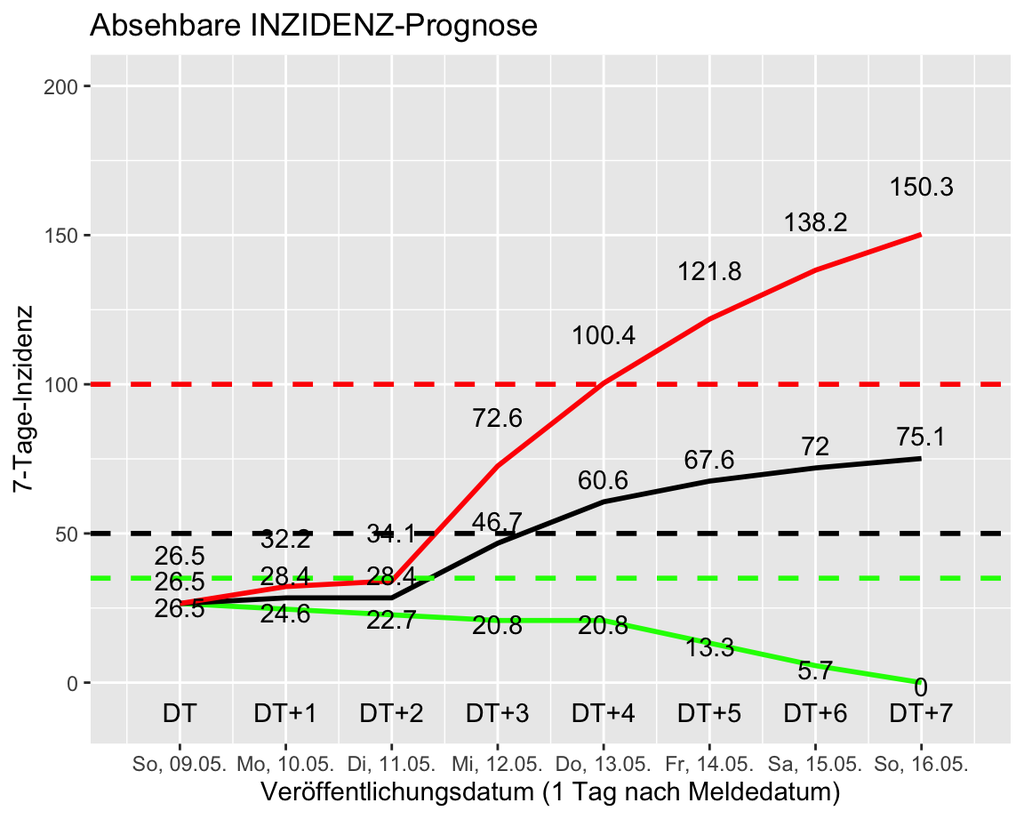

### Prognose der Fallzahlen

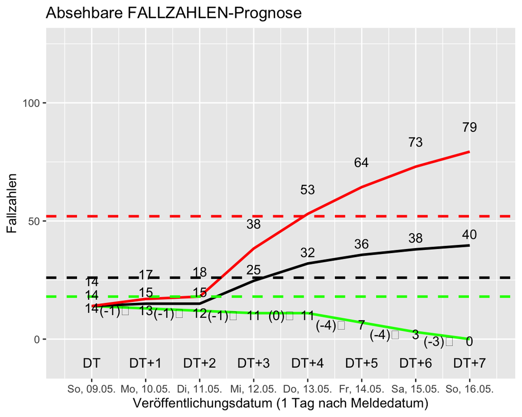

## Datenbasis für die Prognosen

Fallzahlen gehen je nach Wochentag in unterschiedlicher Höhe ein. Basierend auf den letzten 3 Wochen bzw. 21 Tagen ergibt sich folgende Verteilung:

### Fallzahlenrückblick über 3 Wochen:

| Wochentag | Datum | Fälle | Relevant |
| --- | --- | --- | --- |
| Sonntag | 18.04.2021 | 5 | Nicht mehr |
| Montag | 19.04.2021 | 1 | Nicht mehr |
| Dienstag | 20.04.2021 | 20 | Nicht mehr |
| Mittwoch | 21.04.2021 | 13 | Nicht mehr |
| Donnerstag | 22.04.2021 | 13 | Nicht mehr |
| Freitag | 23.04.2021 | 7 | Nicht mehr |
| Samstag | 24.04.2021 | 10 | Nicht mehr |
| Sonntag | 25.04.2021 | 0 | Nicht mehr |
| Montag | 26.04.2021 | 1 | Nicht mehr |
| Dienstag | 27.04.2021 | 11 | Nicht mehr |
| Mittwoch | 28.04.2021 | 9 | Nicht mehr |
| Donnerstag | 29.04.2021 | 6 | Nicht mehr |
| Freitag | 30.04.2021 | 8 | Nicht mehr |
| Samstag | 01.05.2021 | 1 | Nicht mehr |
| Sonntag | 02.05.2021 | 1 | Ja |
| Montag | 03.05.2021 | 1 | Ja |
| Dienstag | 04.05.2021 | 1 | Ja |
| Mittwoch | 05.05.2021 | 0 | Ja |
| Donnerstag | 06.05.2021 | 4 | Ja |
| Freitag | 07.05.2021 | 4 | Ja |
| Samstag | 08.05.2021 | 3 | Ja |

### Fallzahlendurchschnitt je Wochentag

| Wochentag | Mittelwert |
| --- | --- |
| Sonntag | 2.00 |
| Montag | 1.00 |
| Dienstag | 10.67 |
| Mittwoch | 7.33 |
| Donnerstag | 7.67 |
| Freitag | 6.33 |
| Samstag | 4.67 |

# Inzidenzabhängige Öffnungsregelungen

### Unterschreitung von Schwellenwerten

Grenzwerte müssen “dauerhaft” unter- bzw. überschritten sein, bevor die damit verbundenen Regelungen greifen. Das gilt im allgemeinen ab dem dritten Tag der Über-/Unterschreitung als der Fall.

Bei den 7-Tage-Inzidenzen für frühere Tage muss berücksichtigt werden, dass es sich hier um die jeweils an dem angegebenen Tag berichteten Werte handelt, die **nicht** durch an Folgetagen nachübermittelte Fälle aktualisiert werden (für den Berichtstag “eingefrorene” Werte). RKI stellt diese eingefrorenen Werte einschließlich einer mehrmonatigen Rückschau täglich zur Verfügung.

Der hier verwendete Datenstand ist 2021-05-09.

### Vergleich mit den Nachbarn

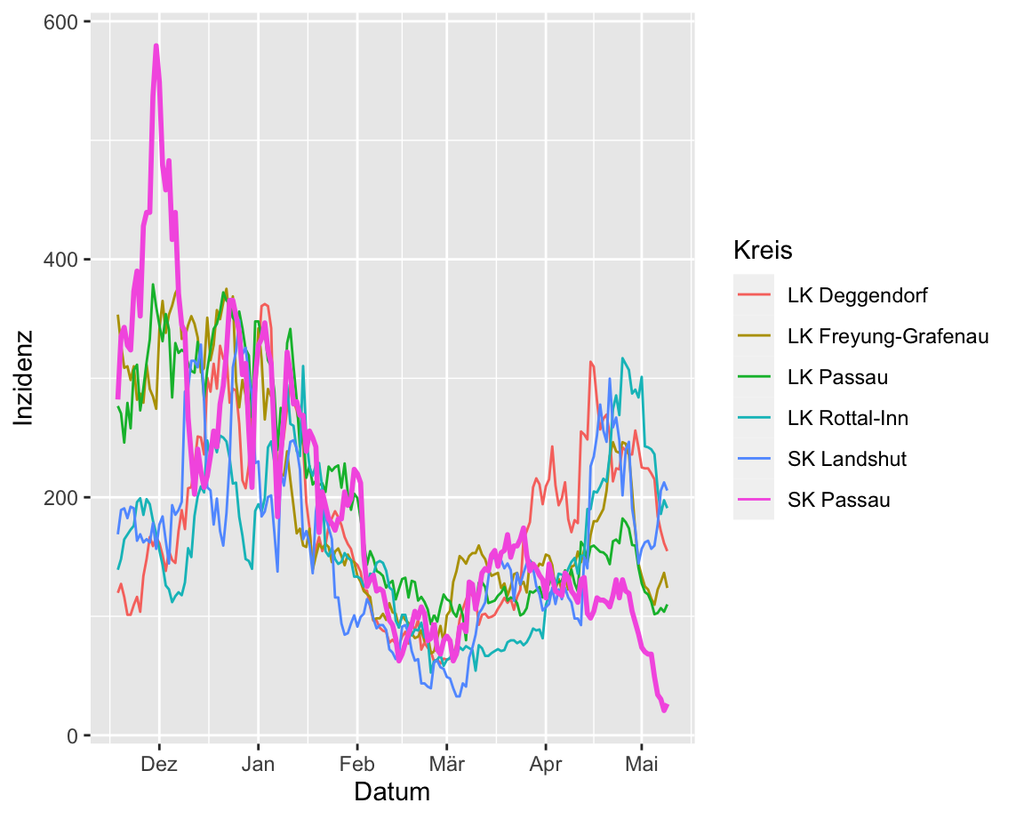

### Grenzwert 35 unterschritten seit

[interactive chart not shown]

### Grenzwert 50 unterschritten seit

[interactive chart not shown]

### Grenzwert 100 unterschritten seit

[interactive chart not shown]

### Grenzwert 150 unterschritten seit

[interactive chart not shown]